# Demo: Functions

NIHES BST02

Nicole Erler, Department of Biostatistics, Erasmus Medical Center

01 January 2020

## Say hello!

### A first function

```r
hello <- function(name) {
  paste0("Hello ", name, ", how are you?")
}

hello("Nicole")
```

```
## [1] "Hello Nicole, how are you?"
```

The function `paste()` seems to concatenate / combine strings. Let’s check out the help file for `paste()`:

```r
?paste
```

`paste()` has arguments

- `...`: one or more R objects, to be converted to character vectors.
- `sep`: a character string to separate the terms. Not NA_character_.
- `collapse`: an optional character string to separate the results. Not NA_character_.

The help file also tells us that `paste0(..., collapse)` is equivalent to `paste(..., sep = "", collapse)`.

### Let’s experiment with this a bit

Note: to experiment with the content of our own function it can be convenient to set the arguments of our function to a value:

```r
name <- "Nicole"
paste0("Hello ", name, ", how are you?") # same as above
```

```
## [1] "Hello Nicole, how are you?"
```

```r
paste("Hello ", name, ", how are you?") # use paste instead of paste0
```

```
## [1] "Hello  Nicole , how are you?"
```

Notice the extra spaces between the text and `name`?

```r
paste("Hello ", name, ", how are you?", sep = "")
```

```
## [1] "Hello Nicole, how are you?"
```

Setting `sep = ""` indeed gives us is the same as `paste0`! We can also `paste` vectors. Note the difference:

```r
paste(c("I", "am", "a", "vector", "of", "character", "strings")) # (sentence 1)
```

```
## [1] "I"         "am"        "a"         "vector"    "of"        "character"
## [7] "strings"
```

```r
paste("We", "are", "several", "character", "strings")            # (sentence 2)
```

```
## [1] "We are several character strings"
```

We can use this to explore the effect of the arguments `sep` and `collapse`:

```r
paste(c("I", "am", "a", "vector", "of", "character", "strings"), sep = "+++")
```

```
## [1] "I"         "am"        "a"         "vector"    "of"        "character"
## [7] "strings"
```

```r
paste(c("I", "am", "a", "vector", "of", "character", "strings"), collapse = "---")
```

```
## [1] "I---am---a---vector---of---character---strings"
```

```r
paste("We", "are", "several", "character", "strings", sep = "+++")
```

```
## [1] "We+++are+++several+++character+++strings"
```

```r
paste("We", "are", "several", "character", "strings", collapse = "---")
```

```
## [1] "We are several character strings"
```

- `sep` separates the different objects. Because the vector `c(...)` is one object it didn’t have effect in sentence 1, Sentence 2 has multiple objects (each word is a separate object).
- `collapse` separates the terms (elements) of an object. This is why it has an effect in sentence 1 (each word is an element of the vector) but not in sentence 2 (each word is only one object).

This is what was written in the help file!

BTW: `paste()` does not only work for character strings:

```r
paste(c(1, 2, "abc"), 345, sep = " a word ", collapse = " / ")
```

```
## [1] "1 a word 345 / 2 a word 345 / abc a word 345"
```

**What should I have learned from this?**

- Read the help files! They (usually) explain how things work!
- Play around with the options / arguments to figure out how things work if you don’t immediately understand the help file.

### Write your own function

Now that we understand `sep` and `collapse`, can you write a function that can greet two people at the same time?

```r
hello2 <- function(name1, name2) {
  paste0("Hello ", name1, " and ", name2, ", how are you?")
}

hello2("Elrozy", "Nicole")
```

```
## [1] "Hello Elrozy and Nicole, how are you?"
```

What about a function that can greet any number of people?

```r
hello_any <- function(names) {
  paste0("Hello ",
         paste(names, collapse = ", "),
         ", how are you?")
}

hello_any(c("Elrozy", "Nicole"))
```

```
## [1] "Hello Elrozy, Nicole, how are you?"
```

```r
hello_any(c("Elrozy", "Nicole", "Anton", 'Daniel'))
```

```
## [1] "Hello Elrozy, Nicole, Anton, Daniel, how are you?"
```

```r
hello_any("Elrozy")
```

```
## [1] "Hello Elrozy, how are you?"
```

**What happens when we give this input to our previous functions?**

```r
hello(c("Elrozy", "Nicole", "Anton", 'Daniel'))
```

```
## [1] "Hello Elrozy, how are you?" "Hello Nicole, how are you?"
## [3] "Hello Anton, how are you?"  "Hello Daniel, how are you?"
```

```r
hello2("Elrozy")
```

```
## Error in paste0("Hello ", name1, " and ", name2, ", how are you?"): argument "name2" is missing, with no default
```

```r
hello2(c("Elrozy", "Nicole", "Anton", 'Daniel'))
```

```
## Error in paste0("Hello ", name1, " and ", name2, ", how are you?"): argument "name2" is missing, with no default
```

**What should I have learned from this?**

- Better knowledge of the use of `paste()`, of course.
- When you write functions, think about what the possible input might be.
- Try your function with different possible inputs.
- It can be useful to write functions general enough to handle different input. Re-inventing the wheel

```r
mymean1 <- function(x) {
  mean(x)
}

mymean2 <- function(x) {
  sum(x)/length(x)
}

# simulate a vector of random numbers:
x <- rnorm(50)

mean(x)
```

```
## [1] 0.07702845
```

```r
mymean1(x)
```

```
## [1] 0.07702845
```

```r
mymean2(x)
```

```
## [1] 0.07702845
```

```r
# t-test
my_t_test <- function(x) {
  # calculate the standard error
  se <- sd(x)/sqrt(length(x))

  # calculate the test statistic
  stat <- mean(x)/se

  # obtain the probability under the null-hypthesis (t-distribution)
  pt(stat, df = length(x) - 1) * 2
}

t.test(x)
```

```
##
##  One Sample t-test
##
## data:  x
## t = 0.45369, df = 49, p-value = 0.6521
## alternative hypothesis: true mean is not equal to 0
## 95 percent confidence interval:
##  -0.2641618  0.4182187
## sample estimates:
##  mean of x
## 0.07702845
```

```r
my_t_test(x)
```

```
## [1] 1.347945
```

```r
my_t_test2 <- function(x) {
  # calculate the standard error
  se <- sd(x)/sqrt(length(x))

  # calculate the test statistic
  stat <- mean(x)/se

  # obtain the probability under the null-hypthesis (t-distribution)
  pval <- pt(stat, df = length(x) - 1) * 2

  return(list(mean = mean(x), std.err = se, stat = stat, "p-value" = pval))
}

my_t_test2(x)
```

```
## $mean
## [1] 0.07702845
##
## $std.err
## [1] 0.1697823
##
## $stat
## [1] 0.4536896
##
## $`p-value`
## [1] 1.347945
```

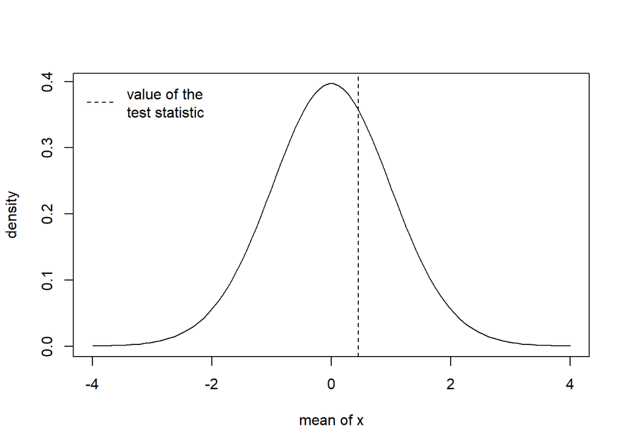

```r
visualise_t_test <- function(x) {
  res <- my_t_test2(x)

  x0 <- seq(from = -4, to = 4, length = 100)
  plot(x0, dt(x0, df = length(x)-1), type = 'l', xlab = "mean of x", ylab = "density")
  abline(v = res$stat, lty = 2)
  legend(x = 'topleft', legend = 'value of the\ntest statistic', lty = 2, col = 1, bty = 'n')
}

visualise_t_test(x)
```

```r
visualise_t_test2 <- function(x, emp = TRUE) {
  res <- my_t_test2(x)

  x0 <- seq(from = -4, to = 4, length = 100)
  plot(x0, dt(x0, df = length(x)-1), type = 'l', xlab = "mean of x", ylab = "density")
  abline(v = res$stat, lty = 2)
  legend(x = 'topleft', legend = 'value of the\ntest statistic', lty = 2, col = 1, bty = 'n')

  if (emp == TRUE)
    lines(density(x), col = 2)
}
```